# Forecasting client retention — A machine-learning approach - ScienceDirect

The accuracies of the ten replicas per each model are shown in Fig. 5; as the accuracy is very similar in the three cases, the medians being nearly identical, the usage of time-consuming options of radial or polynomial variants is unjustified — the fastest option of a linear SVM achieves essentially the same accuracy in much less time. We therefore find no particular necessity for anything but the simplest option, the linear SVM, for this particular data set.

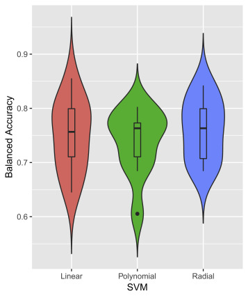

Fig. 5. Accuracies over ten replicas for the three types of SVM using the subset with $ℓ=8$, $λ=22$, and $δ=6$.

We then analyzed the misclassifications made by the ten replicas of the linear SVM among the 38 clients that were used as testing data (out of the 129 clients of each kind — lost or retained — in that subset), the other 70% having been used for training; each replica used a different pseudo-random assignment of the training and the testing data. The complete data set contains 1230 retained clients with data available to this combination of $ℓ=8$, $λ=22$, and $δ=6$, but as there were only 129 lost clients, the data for training was balanced to classes of equal size, as discussed earlier.

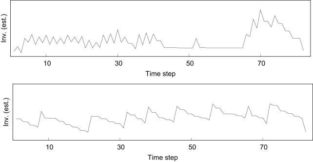

Fig. 6. Time series of clients mislabeled by the classifier with respect to how they were prelabeled by the cut-off rule: a client classified as *retained* but prelabeled as *lost* on the top, and a client classified as *lost* but prelabeled as *retained* on the bottom.

Now, in all of the experiments thus far, the imbalance in the classes — there being few lost clients and an overwhelming majority of retained clients — the test data was also drawn from the balanced data set with half lost and half retained clients. We now report the accuracies while training on a balanced data set but testing on *all* of the remaining data, which includes many more retained than lost clients. In this case, instead of reporting the accuracy per se in which the majority class outweighs the minority one, we report the *balanced accuracy* $Ab$ which is the average of the individual class accuracies, sensitivity and the specificity:(1)$Ab=Se+Sp2,$

Table 5 reports the values of $Ab$, $Sp$ (the success rate at classifying clients correctly as lost), and $Se$ (the success rate at classifying clients correctly as retained) for the data set of $ℓ=8$, $λ=22$, and $δ=6$ where classifiers were trained on balanced data but tested with all of the remaining client data executing 30 replicas of testing resulting classifier in order to determine whether the results are stable.

**•**

30 replicas of a linear SVM using

c = trainControl(method = "boot", number = 30)

p = c("center", "scale")

train(…, method = "svmLinear",

trControl = c, preprocess = p,tunelength = 10)

**•**

*k-nearest neighbor* (KNN) (Cover and Hart, 1967) models varying $k∈[2,8]$ (hence $7×10$ replicas) with

knn3(…, k = k),

**•**

Random Forest (RF) models (30 replicas) (Breiman, 2001) with

train(…, method = "ranger"),

**•**

ADA Boost (ADA; 5 replicas due to elevated runtime) (Freund and Schapire, 1997) with

train(…, method = "ada").

Table 5. A comparison of SVM, KNN, RF, and ADA for the data set with $ℓ=8$, $λ=22$, and $δ=6$. The best value of each measure is indicated in boldface and the worst is underlined.

| Measure |  | SVM | KNN | RF | ADA |
| --- | --- | --- | --- | --- | --- |
| Balanced accuracy $Ab$ | $min$ | 0.680 | $0.282‾$ | 0.725 | 0.739 |
|  | $max$ | 0.799 | 0.444 | **0****.****824** | 0.796 |
| Specificity $Sp$ | $min$ | 0.711 | $0.158‾$ | 0.710 | 0.684 |
|  | $max$ | 0.842 | 0.395 | **0****.****921** | 0.816 |
| Sensitivity $Se$ | $min$ | 0.642 | $0.359‾$ | 0.721 | 0.716 |
|  | $max$ | 0.669 | 0.619 | 0.805 | **0****.****816** |
| Runtime (in seconds) | $min$ | 0.742 | **0****.****001** | 3.632 | 59.502 |
|  | $max$ | 1.184 | 0.002 | 4.057 | $60.541‾$ |

We include the KNN models as a baseline as they are computationally very simple — anything that performs worse than KNN in terms of accuracy is simply not worth the effort. Random Forest and ADA Boost are included for having performed well in existing literature for similar tasks (Sabbeh, 2018).

Classifying clients correctly as retained is considered the easier of the two tasks, so the measure of major interest is the peak specificity, in which Random Forest is the best-performing option, with SVM in second place. In terms of quality measures ($Ab$, $Sp$, $Se$), KNN is always the worst option, albeit undeniably the fastest, as was expected. Random Forest shows the highest values for balanced accuracy and specificity with a reasonable runtime, whereas ADA Boost has the best sensitivity but takes a minute to train even with these small data sets whereas Random Forest only takes a few seconds and SVM requires approximately 1 s. As the maximum quality measures achieved by SVM are above the minimum values of ADA Boost for both balanced accuracy and specificity, the extra cost in the runtime cannot be justified. We expect the sensitivity of all models to improve if more data is added; it is important to keep in mind that only 129 lost clients exist in total in our data set for the combination of $ℓ,λ,δ$ used in this comparative study.

## 4. Discussion

For scenarios where client retention needs to be forecast infrequently for small or medium data sets (similar to the one used in this work), our findings indicate that Random Forest is the best option, whereas, for near real-time forecasting for large data sets, SVM may prove adequate and much faster than Random Forest — this latter option makes sense when the data arrives and is analyzed on a minute-by-minute bases, whereas hourly, daily, weekly, or monthly processing allows for more time-consuming models to be trained.

Being able to single out clients that may potentially soon be lost with a three-month horizon is of practical commercial interest, as the marketing department has ample opportunity to reach out to the clients with retention-oriented promotions. It is also important to note that in the practice, reaching out to a client that was mistakenly thought to be in danger to be lost is not as serious of an error as not reaching out to one that actually would be lost, so the false negatives for the client-loss category are the main cause of concern. Only having to contact the clients that were labeled to be at risk of loss by the ML algorithm greatly reduces the number of clients that need to be targeted by the marketing department, saving the company time and money.

## 5. Conclusions

We work with data from prepurchase and usage of unitary services in a business-to-business setting with the goal of identifying potential future client loss with a machine-learning (ML) approach. We train classifiers with time series that estimate the client-side inventory and classify the clients as lost or retained in terms of periods of inactivity in both the usage and the prepurchase of the unitary service provided by the company. We explore different lengths of the time series used as input to the ML algorithm, different lengths for the period of inactivity that label a client as lost, and different forecast horizons, that is, how much in advance the client loss is being detected. We find that a linear SVM performs acceptably for a wide range of the three parameters: the time-series length, the length of the inactivity period, and the forecast horizon. The best performance for predicting lost clients is achieved by Random Forest with a specificity up to 92 percent.

In future work, we hope to train models with larger data sets, enrich the features extracted from the time series describing the client transactions, incorporate other types of client-relation data into the ML inputs, as well as to explore how well our proposed approach extends to business-to-consumer sales such as prepaid cellular services. We are also interested in semi-supervised models and settings in which the model is partially or completely retrained as new data arrives.

## References

**Ali and Arıtürk, 2014**

Ö.G. Ali, U. Arıtürk**Dynamic churn prediction framework with more effective use of rare event data: the case of private banking**

Expert Syst. Appl., 41 (17) (2014), pp. 7889-7903

Google Scholar

**Amin et al., 2019**

A. Amin, F. Al-Obeidat, B. Shah, A. Adnan, J. Loo, S. Anwar**Customer churn prediction in telecommunication industry using data certainty**

J. Bus. Res., 94 (Jan. 2019), pp. 290-301

[Article](https://www.sciencedirect.com/science/article/pii/S0148296318301231)[Download PDF](https://www.sciencedirect.com/science/article/pii/S0148296318301231/pdfft?md5=4b89f5302d7281d394e7a01501f4e2ea&pid=1-s2.0-S0148296318301231-main.pdf)[View Record in Scopus](https://www.scopus.com/inward/record.url?eid=2-s2.0-85044089289&partnerID=10&rel=R3.0.0)[Google Scholar](https://scholar.google.com/scholar?q=Customer%20churn%20prediction%20in%20telecommunication%20industry%20using%20data%20certainty)

**Ankenbruck, 2017**

S. Ankenbruck**Churn the data around — a machine learning approach to understanding why customers leave**

Conference of the SouthEast SAS Users Group (2017), p. 191

[View Record in Scopus](https://www.scopus.com/inward/record.url?eid=2-s2.0-85071739466&partnerID=10&rel=R3.0.0)[Google Scholar](https://scholar.google.com/scholar?q=Churn%20the%20data%20around%20%20a%20machine%20learning%20approach%20to%20understanding%20why%20customers%20leave)

**Ballings and Van den Poel, 2012**

M. Ballings, D. Van den Poel**Customer event history for churn prediction: how long is long enough?**

Expert Syst. Appl., 39 (18) (2012), pp. 13517-13522

[Article](https://www.sciencedirect.com/science/article/pii/S0957417412008615)[Download PDF](https://www.sciencedirect.com/science/article/pii/S0957417412008615/pdfft?md5=3a139d368d6163ebddad58fbf4e18d48&pid=1-s2.0-S0957417412008615-main.pdf)[View Record in Scopus](https://www.scopus.com/inward/record.url?eid=2-s2.0-84865244941&partnerID=10&rel=R3.0.0)[Google Scholar](https://scholar.google.com/scholar?q=Customer%20event%20history%20for%20churn%20prediction:%20how%20long%20is%20long%20enough)

**Breiman, 2001**

L. Breiman**Random forests**

Mach. Learn., 45 (1) (Oct. 2001), pp. 5-32

[CrossRef](https://doi.org/10.1023/A:1010933404324)[View Record in Scopus](https://www.scopus.com/inward/record.url?eid=2-s2.0-0035478854&partnerID=10&rel=R3.0.0)[Google Scholar](https://scholar.google.com/scholar?q=Random%20forests)

**Breiman et al., 1984**

L. Breiman, J. Friedman, C.J. Stone, R.A. Olshen**Classification and Regression Trees**

(first ed.), Chapman and Hall/CRC (1984)

[Google Scholar](https://scholar.google.com/scholar_lookup?title=Classification%20and%20Regression%20Trees&publication_year=1984&author=L.%20Breiman&author=J.%20Friedman&author=C.J.%20Stone&author=R.A.%20Olshen)

**Chen et al., 2012**

Z.-Y. Chen, Z.-P. Fan, M. Sun**A hierarchical multiple kernel support vector machine for customer churn prediction using longitudinal behavioral data**

Eur. J. Oper. Res., 223 (2) (2012), pp. 461-472

[Article](https://www.sciencedirect.com/science/article/pii/S037722171200495X)[Download PDF](https://www.sciencedirect.com/science/article/pii/S037722171200495X/pdfft?md5=484a7930906f0928b309dfb78098e049&pid=1-s2.0-S037722171200495X-main.pdf)[View Record in Scopus](https://www.scopus.com/inward/record.url?eid=2-s2.0-84864609860&partnerID=10&rel=R3.0.0)Google Scholar

**Cortes and Vapnik, 1995**

C. Cortes, V. Vapnik**Support-vector networks**

Mach. Learn., 20 (3) (Sep. 1995), pp. 273-297

[CrossRef](https://doi.org/10.1007/BF00994018)[View Record in Scopus](https://www.scopus.com/inward/record.url?eid=2-s2.0-0141645287&partnerID=10&rel=R3.0.0)[Google Scholar](https://scholar.google.com/scholar?q=Support-vector%20networks)

**Coussement et al., 2010**

K. Coussement, D.F. Benoit, D. Van den Poel**Improved marketing decision making in a customer churn prediction context using generalized additive models**

Expert Syst. Appl., 37 (3) (2010), pp. 2132-2143

[Article](https://www.sciencedirect.com/science/article/pii/S0957417409007325)[Download PDF](https://www.sciencedirect.com/science/article/pii/S0957417409007325/pdfft?md5=d02376cf7cc8933a89472318c832c1a3&pid=1-s2.0-S0957417409007325-main.pdf)[View Record in Scopus](https://www.scopus.com/inward/record.url?eid=2-s2.0-70449526531&partnerID=10&rel=R3.0.0)Google Scholar

**Coussement and Van den Poel, 2008**

K. Coussement, D. Van den Poel**Churn prediction in subscription services: an application of support vector machines while comparing two parameter-selection techniques**

Expert Syst. Appl., 34 (1) (2008), pp. 313-327

[Article](https://www.sciencedirect.com/science/article/pii/S0957417406002806)[Download PDF](https://www.sciencedirect.com/science/article/pii/S0957417406002806/pdfft?md5=942186048f1b9a6aa536115088302e29&pid=1-s2.0-S0957417406002806-main.pdf)[View Record in Scopus](https://www.scopus.com/inward/record.url?eid=2-s2.0-34248524002&partnerID=10&rel=R3.0.0)Google Scholar

**Cover and Hart, 1967**

T. Cover, P.E. Hart**Nearest neighbor pattern classification**

IEEE Trans. Inf. Theory, 13 (1) (Jan. 1967), pp. 21-27

[CrossRef](https://doi.org/10.1109/TIT.1967.1053964)[View Record in Scopus](https://www.scopus.com/inward/record.url?eid=2-s2.0-0001845324&partnerID=10&rel=R3.0.0)[Google Scholar](https://scholar.google.com/scholar?q=Nearest%20neighbor%20pattern%20classification)

**De Bock and Van den Poel, 2011**

K.W. De Bock, D. Van den Poel**An empirical evaluation of rotation-based ensemble classifiers for customer churn prediction**

Expert Syst. Appl., 38 (10) (2011), pp. 12293-12301

[Article](https://www.sciencedirect.com/science/article/pii/S0957417411005239)[Download PDF](https://www.sciencedirect.com/science/article/pii/S0957417411005239/pdfft?md5=646302d1aef320dc9df5464e2e16211a&pid=1-s2.0-S0957417411005239-main.pdf)[View Record in Scopus](https://www.scopus.com/inward/record.url?eid=2-s2.0-79958004813&partnerID=10&rel=R3.0.0)Google Scholar

**De Bock and Van den Poel, 2012**

K.W. De Bock, D. Van den Poel**Reconciling performance and interpretability in customer churn prediction using ensemble learning based on generalized additive models**

Expert Syst. Appl., 39 (8) (2012), pp. 6816-6826

[Article](https://www.sciencedirect.com/science/article/pii/S0957417412000164)[Download PDF](https://www.sciencedirect.com/science/article/pii/S0957417412000164/pdfft?md5=740e5a71e20e6cdd31918d6c59950934&pid=1-s2.0-S0957417412000164-main.pdf)[View Record in Scopus](https://www.scopus.com/inward/record.url?eid=2-s2.0-84857651191&partnerID=10&rel=R3.0.0)Google Scholar

**De Caigny et al., 2018**

A. De Caigny, K. Coussement, K.W. De Bock**A new hybrid classification algorithm for customer churn prediction based on logistic regression and decision trees**

Eur. J. Oper. Res., 269 (2) (2018), pp. 760-772

[Article](https://www.sciencedirect.com/science/article/pii/S0377221718301243)[Download PDF](https://www.sciencedirect.com/science/article/pii/S0377221718301243/pdfft?md5=994779cd59cb4ff8cd6a0311ca44428c&pid=1-s2.0-S0377221718301243-main.pdf)[View Record in Scopus](https://www.scopus.com/inward/record.url?eid=2-s2.0-85042590006&partnerID=10&rel=R3.0.0)Google Scholar

**Derby, 2018**

N. Derby**Reducing customer attrition with machine learning for financial institutions**

Proceedings of the SAS Global Forum (2018), p. 1796

[View Record in Scopus](https://www.scopus.com/inward/record.url?eid=2-s2.0-85071749613&partnerID=10&rel=R3.0.0)[Google Scholar](https://scholar.google.com/scholar_lookup?title=Reducing%20customer%20attrition%20with%20machine%20learning%20for%20financial%20institutions&publication_year=2018&author=N.%20Derby)

**Freund and Schapire, 1997**

Y. Freund, R.E. Schapire**A decision-theoretic generalization of on-line learning and an application to boosting**

J. Comput. Syst. Sci., 55 (1) (Aug. 1997), pp. 119-139

[Article](https://www.sciencedirect.com/science/article/pii/S002200009791504X)[Download PDF](https://www.sciencedirect.com/science/article/pii/S002200009791504X/pdf?md5=e471323f84c2764746c94ba206a9bc47&pid=1-s2.0-S002200009791504X-main.pdf)[View Record in Scopus](https://www.scopus.com/inward/record.url?eid=2-s2.0-0031211090&partnerID=10&rel=R3.0.0)[Google Scholar](https://scholar.google.com/scholar?q=A%20decision-theoretic%20generalization%20of%20on-line%20learning%20and%20an%20application%20to%20boosting)

**Huang et al., 2015**

Y. Huang, F. Zhu, M. Yuan, K. Deng, Y. Li, B. Ni, W. Dai, Q. Yang, J. Zeng**Telco churn prediction with big data**

Proceedings of the 2015 ACM SIGMOD International Conference on Management of Data, ACM, New York, NY, USA (2015), pp. 607-618

[CrossRef](https://doi.org/10.1145/2723372.2742794)[View Record in Scopus](https://www.scopus.com/inward/record.url?eid=2-s2.0-84953860811&partnerID=10&rel=R3.0.0)Google Scholar

**Jahromi et al., 2014**

A.T. Jahromi, S. Stakhovych, M. Ewing**Managing b2b customer churn, retention and profitability**

Ind. Mark. Manag., 43 (7) (2014), pp. 1258-1268

[View Record in Scopus](https://www.scopus.com/inward/record.url?eid=2-s2.0-84909998420&partnerID=10&rel=R3.0.0)[Google Scholar](https://scholar.google.com/scholar_lookup?title=Managing%20b2b%20customer%20churn%2C%20retention%20and%20profitability&publication_year=2014&author=A.T.%20Jahromi&author=S.%20Stakhovych&author=M.%20Ewing)

**Karp, 1998**

A.H. Karp**Using logistic regression to predict customer retention**

Proceedings of the Eleventh Northeast SAS Users Group Conference (1998), p. 095

[Google Scholar](https://scholar.google.com/scholar_lookup?title=Using%20logistic%20regression%20to%20predict%20customer%20retention&publication_year=1998&author=A.H.%20Karp)

**Kleinbaum and Klein, 2010**

D.G. Kleinbaum, M. Klein**Logistic Regression — A Self-Learning Text**

(third ed.), Statistics for Biology and Health. Springer (2010)

[Google Scholar](https://scholar.google.com/scholar?q=Logistic%20Regression%20%20A%20Self-Learning%20Text)

**Kracklauer et al., 2004**

A.H. Kracklauer, D.Q. Mills, D. Seifert**Customer management as the origin of collaborative customer relationship management**

A.H. Kracklauer, D.Q. Mills, D. Seifert (Eds.), Collaborative Customer Relationship Management: Taking CRM to the Next Level, Springer, Berlin, Heidelberg, Germany (2004), pp. 3-6

[CrossRef](https://doi.org/10.1007/978-3-540-24710-4_1)[View Record in Scopus](https://www.scopus.com/inward/record.url?eid=2-s2.0-56349116511&partnerID=10&rel=R3.0.0)Google Scholar

**Larivière and Van den Poel, 2005**

B. Larivière, D. Van den Poel**Predicting customer retention and profitability by using random forests and regression forests techniques**

Expert Syst. Appl., 29 (2) (2005), pp. 472-484

[Article](https://www.sciencedirect.com/science/article/pii/S0957417405000965)[Download PDF](https://www.sciencedirect.com/science/article/pii/S0957417405000965/pdfft?md5=5a4575facc28d83b8bc53a82ee0c913e&pid=1-s2.0-S0957417405000965-main.pdf)[View Record in Scopus](https://www.scopus.com/inward/record.url?eid=2-s2.0-22144481002&partnerID=10&rel=R3.0.0)Google Scholar

**Ling and Yen, 2016**

R. Ling, D.C. Yen**Customer relationship management: an analysis framework and implementation strategies**

J. Comput. Inf. Syst., 41 (3) (2016), pp. 82-97

[View Record in Scopus](https://www.scopus.com/inward/record.url?eid=2-s2.0-85062816816&partnerID=10&rel=R3.0.0)[Google Scholar](https://scholar.google.com/scholar_lookup?title=Customer%20relationship%20management%3A%20an%20analysis%20framework%20and%20implementation%20strategies&publication_year=2016&author=R.%20Ling&author=D.C.%20Yen)

**Marsland, 2014**

S. Marsland**Machine Learning: an Algorithmic Perspective**

(second ed.), CRC Press, Boca Raton, Florida, USA (2014)

[Google Scholar](https://scholar.google.com/scholar_lookup?title=Machine%20Learning%3A%20an%20Algorithmic%20Perspective&publication_year=2014&author=S.%20Marsland)

**Martínez et al., 2018**

A. Martínez, C. Schmuck, S. Pereverzyev Jr., C. Pirker, M. Haltmeier**A machine learning framework for customer purchase prediction in the non-contractual setting**

Eur. J. Oper. Res. (2018)

Google Scholar

**Miguéis et al., 2013**

V.L. Miguéis, A. Camanho, J.F. e Cunha**Customer attrition in retailing: an application of multivariate adaptive regression splines**

Expert Syst. Appl., 40 (16) (2013), pp. 6225-6232

[Article](https://www.sciencedirect.com/science/article/pii/S0957417413003679)[Download PDF](https://www.sciencedirect.com/science/article/pii/S0957417413003679/pdfft?md5=b6d3a612502c5d68b4c737c28c834d9f&pid=1-s2.0-S0957417413003679-main.pdf)[View Record in Scopus](https://www.scopus.com/inward/record.url?eid=2-s2.0-84879492175&partnerID=10&rel=R3.0.0)Google Scholar

**Ngai et al., 2009**

E.W.T. Ngai, L. Xiu, D.C.K. Chau**Application of data mining techniques in customer relationship management: a literature review and classification**

Expert Syst. Appl., 36 (2) (2009), pp. 2592-2602

[Article](https://www.sciencedirect.com/science/article/pii/S0957417408001243)[Download PDF](https://www.sciencedirect.com/science/article/pii/S0957417408001243/pdfft?md5=a11ac034ebfadc8616e84aeab8d26c9f&pid=1-s2.0-S0957417408001243-main.pdf)[View Record in Scopus](https://www.scopus.com/inward/record.url?eid=2-s2.0-56349094668&partnerID=10&rel=R3.0.0)Google Scholar

**Parvatiyar and Sheth, 2001**

A. Parvatiyar, J.N. Sheth**Customer relationship management: emerging practice, process, and discipline**

J. Econ. Soc. Res., 3 (2) (2001), pp. 1-34

Google Scholar

**Risselada et al., 2010**

H. Risselada, P.C. Verhoef, T.H.A. Bijmolt**Staying power of churn prediction models**

J. Interact. Mark., 24 (3) (2010), pp. 198-208

[Article](https://www.sciencedirect.com/science/article/pii/S1094996810000253)[Download PDF](https://www.sciencedirect.com/science/article/pii/S1094996810000253/pdfft?md5=131cf388f385e2f6d2d674c4e10c6372&pid=1-s2.0-S1094996810000253-main.pdf)[View Record in Scopus](https://www.scopus.com/inward/record.url?eid=2-s2.0-77955637474&partnerID=10&rel=R3.0.0)[Google Scholar](https://scholar.google.com/scholar_lookup?title=Staying%20power%20of%20churn%20prediction%20models&publication_year=2010&author=H.%20Risselada&author=P.C.%20Verhoef&author=T.H.A.%20Bijmolt)

**Sabbeh, 2018**

S.F. Sabbeh**Machine-learning techniques for customer retention: a comparative study**

Int. J. Adv. Comput. Sci. Appl., 9 (2) (2018), pp. 273-281

[View Record in Scopus](https://www.scopus.com/inward/record.url?eid=2-s2.0-85049524870&partnerID=10&rel=R3.0.0)[Google Scholar](https://scholar.google.com/scholar_lookup?title=Machine-learning%20techniques%20for%20customer%20retention%3A%20a%20comparative%20study&publication_year=2018&author=S.F.%20Sabbeh)

**Soltani and Navimipour, 2016**

Z. Soltani, N.J. Navimipour**Customer relationship management mechanisms: a systematic review of the state of the art literature and recommendations for future research**

Comput. Hum. Behav., 61 (Aug. 2016), pp. 667-688

[Article](https://www.sciencedirect.com/science/article/pii/S0747563216301704)[Download PDF](https://www.sciencedirect.com/science/article/pii/S0747563216301704/pdfft?md5=a526d71bec51a23c4f78d62f9e6150e1&pid=1-s2.0-S0747563216301704-main.pdf)[View Record in Scopus](https://www.scopus.com/inward/record.url?eid=2-s2.0-84962407423&partnerID=10&rel=R3.0.0)Google Scholar

**Swift, 2000**

R.S. Swift**Accelerating Customer Relationships: Using Crm and Relationship Technologies**

Prentice Hall, Upper Saddle River, NJ, USA (2000)

[Google Scholar](https://scholar.google.com/scholar_lookup?title=Accelerating%20Customer%20Relationships%3A%20Using%20Crm%20and%20Relationship%20Technologies&publication_year=2000&author=R.S.%20Swift)

**Tsai and Lu, 2009**

C.-F. Tsai, Y.-H. Lu**Customer churn prediction by hybrid neural networks**

Expert Syst. Appl., 36 (10) (2009), pp. 12547-12553

[Article](https://www.sciencedirect.com/science/article/pii/S0957417409004758)[Download PDF](https://www.sciencedirect.com/science/article/pii/S0957417409004758/pdfft?md5=8e05eb14a5228fcd58b01c3d52c35b36&pid=1-s2.0-S0957417409004758-main.pdf)[View Record in Scopus](https://www.scopus.com/inward/record.url?eid=2-s2.0-69249209759&partnerID=10&rel=R3.0.0)[Google Scholar](https://scholar.google.com/scholar_lookup?title=Customer%20churn%20prediction%20by%20hybrid%20neural%20networks&publication_year=2009&author=C.-F.%20Tsai&author=Y.-H.%20Lu)

**Verbeke et al., 2012**

W. Verbeke, K. Dejaeger, D. Martens, J. Hur, B. Baesens**New insights into churn prediction in the telecommunication sector: a profit driven data mining approach**

Eur. J. Oper. Res., 218 (1) (2012), pp. 211-229

[Article](https://www.sciencedirect.com/science/article/pii/S0377221711008599)[Download PDF](https://www.sciencedirect.com/science/article/pii/S0377221711008599/pdfft?md5=d7bef473d8613d8e0b30f776f9bb2a67&pid=1-s2.0-S0377221711008599-main.pdf)[View Record in Scopus](https://www.scopus.com/inward/record.url?eid=2-s2.0-83955164226&partnerID=10&rel=R3.0.0)Google Scholar